# Chapter 10

Amanda P

2/11/2018

# 10.2.3 Exercises

1. Practice your filtering skills by:

Finding all the diamonds with equal x and y dimensions

```r
filter(diamonds,x==y)
```

```
## # A tibble: 17 x 10
##    carat       cut color clarity depth table price     x     y     z
##    <dbl>     <ord> <ord>   <ord> <dbl> <dbl> <int> <dbl> <dbl> <dbl>
##  1  0.30     Ideal     H    VVS2  62.5    54   567  4.30  4.30  2.70
##  2  0.27 Very Good     F    VVS1  62.0    55   591  4.16  4.16  2.59
##  3  1.00 Very Good     H     VS2  63.3    53  5139  0.00  0.00  0.00
##  4  1.14      Fair     G     VS1  57.5    67  6381  0.00  0.00  0.00
##  5  1.00   Premium     E     VS2  60.0    60  6600  6.43  6.43  3.89
##  6  1.00   Premium     E     VS2  60.0    60  6720  6.43  6.43  3.89
##  7  1.22   Premium     G     SI2  62.4    61  6969  6.79  6.79  4.23
##  8  1.56     Ideal     G     VS2  62.2    54 12800  0.00  0.00  0.00
##  9  1.20   Premium     D    VVS1  62.1    59 15686  0.00  0.00  0.00
## 10  2.25   Premium     H     SI2  62.8    59 18034  0.00  0.00  0.00
## 11  0.32     Ideal     D    VVS2  62.1    54   858  4.40  4.40  2.74
## 12  0.42     Ideal     H    VVS1  62.8    57  1108  4.79  4.79  3.01
## 13  0.61   Premium     G     SI1  60.8    60  1255  5.42  5.42  3.31
## 14  0.48     Ideal     F     VS2  62.4    54  1279  5.03  5.03  3.15
## 15  0.51   Premium     F     SI1  61.4    59  1421  5.13  5.13  3.16
## 16  0.71      Good     F     SI2  64.1    60  2130  0.00  0.00  0.00
## 17  0.71      Good     F     SI2  64.1    60  2130  0.00  0.00  0.00
```

A depth between 55 and 70:

```r
filter(diamonds,depth >= 55, depth <= 70)
```

```
## # A tibble: 53,895 x 10
##    carat       cut color clarity depth table price     x     y     z
##    <dbl>     <ord> <ord>   <ord> <dbl> <dbl> <int> <dbl> <dbl> <dbl>
##  1  0.23     Ideal     E     SI2  61.5    55   326  3.95  3.98  2.43
##  2  0.21   Premium     E     SI1  59.8    61   326  3.89  3.84  2.31
##  3  0.23      Good     E     VS1  56.9    65   327  4.05  4.07  2.31
##  4  0.29   Premium     I     VS2  62.4    58   334  4.20  4.23  2.63
##  5  0.31      Good     J     SI2  63.3    58   335  4.34  4.35  2.75
##  6  0.24 Very Good     J    VVS2  62.8    57   336  3.94  3.96  2.48
##  7  0.24 Very Good     I    VVS1  62.3    57   336  3.95  3.98  2.47
##  8  0.26 Very Good     H     SI1  61.9    55   337  4.07  4.11  2.53
##  9  0.22      Fair     E     VS2  65.1    61   337  3.87  3.78  2.49
## 10  0.23 Very Good     H     VS1  59.4    61   338  4.00  4.05  2.39
## # ... with 53,885 more rows
```

A carat smaller than the median carat:

```r
filter(diamonds,carat < median(carat))
```

```
## # A tibble: 25,181 x 10
##    carat       cut color clarity depth table price     x     y     z
##    <dbl>     <ord> <ord>   <ord> <dbl> <dbl> <int> <dbl> <dbl> <dbl>
##  1  0.23     Ideal     E     SI2  61.5    55   326  3.95  3.98  2.43
##  2  0.21   Premium     E     SI1  59.8    61   326  3.89  3.84  2.31
##  3  0.23      Good     E     VS1  56.9    65   327  4.05  4.07  2.31
##  4  0.29   Premium     I     VS2  62.4    58   334  4.20  4.23  2.63
##  5  0.31      Good     J     SI2  63.3    58   335  4.34  4.35  2.75
##  6  0.24 Very Good     J    VVS2  62.8    57   336  3.94  3.96  2.48
##  7  0.24 Very Good     I    VVS1  62.3    57   336  3.95  3.98  2.47
##  8  0.26 Very Good     H     SI1  61.9    55   337  4.07  4.11  2.53
##  9  0.22      Fair     E     VS2  65.1    61   337  3.87  3.78  2.49
## 10  0.23 Very Good     H     VS1  59.4    61   338  4.00  4.05  2.39
## # ... with 25,171 more rows
```

Cost more than $10,000 per carat:

```r
filter(diamonds, round(price/carat, digits=2) > 10000)
```

```
## # A tibble: 617 x 10
##    carat       cut color clarity depth table price     x     y     z
##    <dbl>     <ord> <ord>   <ord> <dbl> <dbl> <int> <dbl> <dbl> <dbl>
##  1  0.63     Ideal     D      IF  62.5    55  6549  5.47  5.50  3.43
##  2  0.63     Ideal     D      IF  62.5    55  6607  5.50  5.47  3.43
##  3  0.90 Very Good     D      IF  62.4    54  9182  6.17  6.21  3.86
##  4  0.91     Ideal     E    VVS1  61.7    56  9636  6.18  6.23  3.83
##  5  1.00 Very Good     F      IF  63.2    63 10046  6.26  6.24  3.95
##  6  1.00   Premium     D    VVS2  61.6    60 10046  6.41  6.36  3.93
##  7  1.00     Ideal     F    VVS1  62.3    53 10058  6.37  6.43  3.99
##  8  1.00 Very Good     D    VVS2  61.7    58 10113  6.37  6.41  3.94
##  9  1.00   Premium     E    VVS1  60.3    54 10134  6.59  6.47  3.94
## 10  1.01   Premium     D    VVS2  60.2    58 10147  6.57  6.51  3.94
## # ... with 607 more rows
```

Are of good or better quality:

```r
filter(diamonds, cut >= "Good")
```

```
## # A tibble: 52,330 x 10
##    carat       cut color clarity depth table price     x     y     z
##    <dbl>     <ord> <ord>   <ord> <dbl> <dbl> <int> <dbl> <dbl> <dbl>
##  1  0.23     Ideal     E     SI2  61.5    55   326  3.95  3.98  2.43
##  2  0.21   Premium     E     SI1  59.8    61   326  3.89  3.84  2.31
##  3  0.23      Good     E     VS1  56.9    65   327  4.05  4.07  2.31
##  4  0.29   Premium     I     VS2  62.4    58   334  4.20  4.23  2.63
##  5  0.31      Good     J     SI2  63.3    58   335  4.34  4.35  2.75
##  6  0.24 Very Good     J    VVS2  62.8    57   336  3.94  3.96  2.48
##  7  0.24 Very Good     I    VVS1  62.3    57   336  3.95  3.98  2.47
##  8  0.26 Very Good     H     SI1  61.9    55   337  4.07  4.11  2.53
##  9  0.23 Very Good     H     VS1  59.4    61   338  4.00  4.05  2.39
## 10  0.30      Good     J     SI1  64.0    55   339  4.25  4.28  2.73
## # ... with 52,320 more rows
```

2. Fill in the question marks in the table:

Given table:

[output not shown]

| Expression | TRUE | FALSE | NA |
| --- | --- | --- | --- |
| x | X |  |  |
| !x |  | X |  |
| is.na(x) |  |  | X |
| !is.na(x) | ? | ? | ? |
| ? | X |  | X |
| ? |  | X | X |

TODO: Finish above table. I’m not exactly sure what it’s asking. Is x the same expression from row to row?

3. Repeat the analysis of outlying values with $z$. Compared to $x$ and $y$, how would you characterize the relationship of $x$ and $z$, or $y$ and $z$?

Analysis of $x$ and $z$:

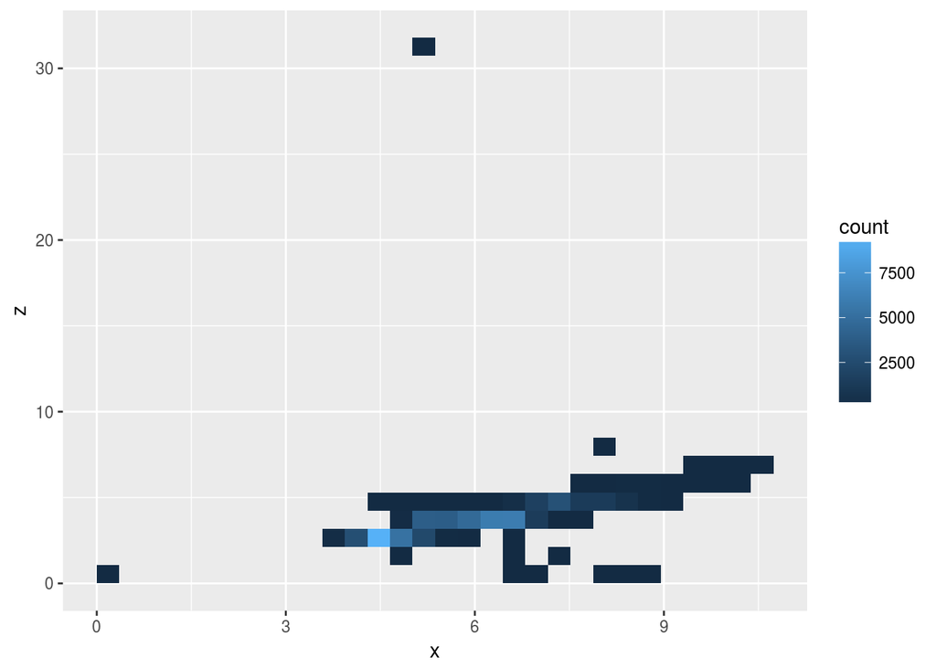

```r
ggplot(diamonds, aes(x,z)) + geom_bin2d()
```

Next filter out points where $x$ or $z$ are 0. Also, filter out large $z$ values (greater than 30).

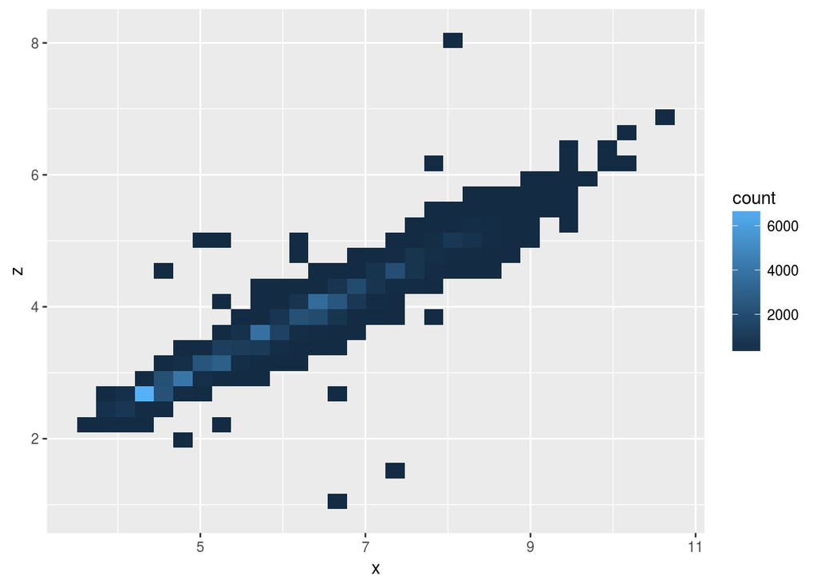

```r
diamondsFiltered <- filter(diamonds, x>0, z>0, z<30)
ggplot(diamondsFiltered, aes(x,z)) + geom_bin2d()
```

We can see in the above plot that $x$ and $z$ have a linear relationship.

Next consider $y$ and $z$:

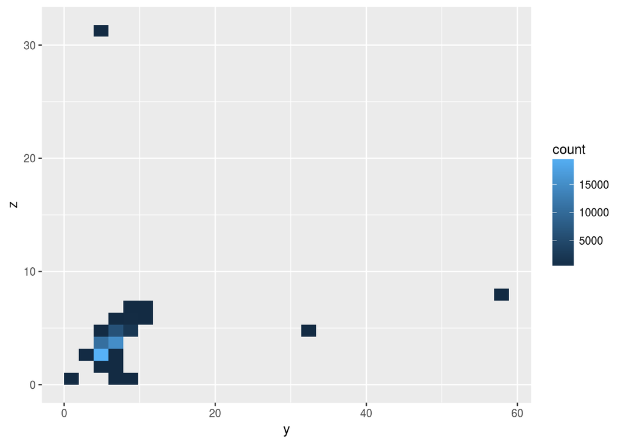

```r
ggplot(diamonds, aes(y,z)) + geom_bin2d()
```

Let’s filter out outliers (y>30 or z>30) and remove zeros:

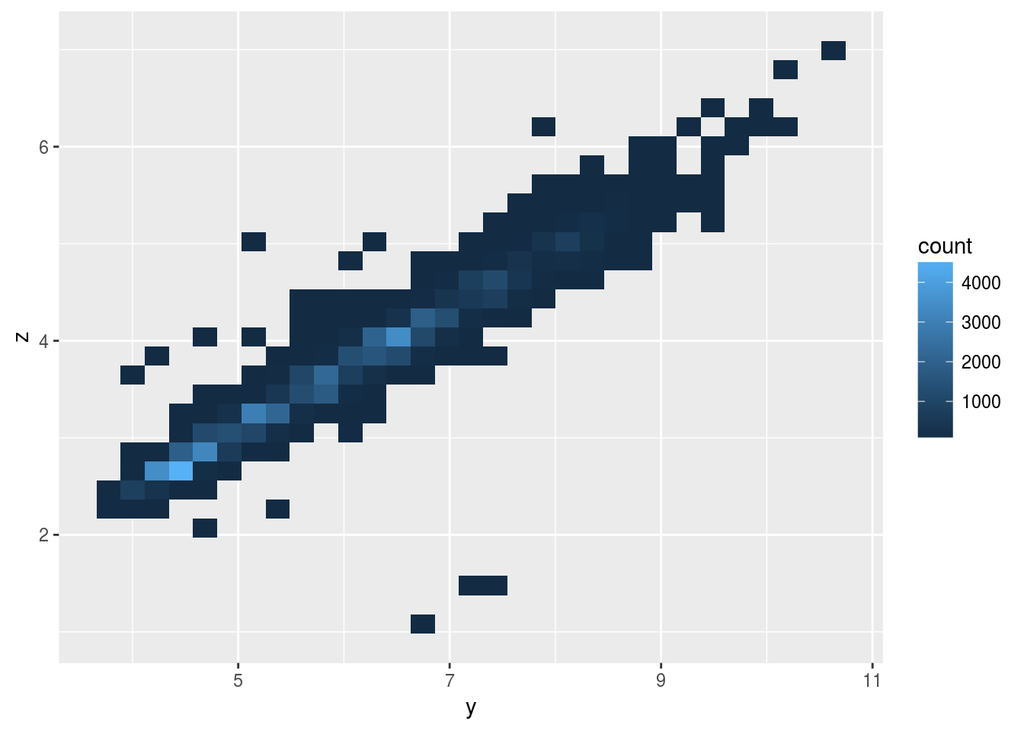

```r
diamondsFiltered <- filter(diamonds, z<30, y<30, z>0, y>0)
ggplot(diamondsFiltered, aes(y,z)) + geom_bin2d()
```

We see in the plot above that $y$ and $z$ also have a linear relationship.

4. Install the `ggplot2movies` package and look at the movies that have a missing budget. How are they different from the movies with a budget? (Hint: try a frequency polygon plus coor = is.na(budget))

```r
#install.packages("ggplot2movies")
library("ggplot2movies")
filter(movies,is.na(budget))
```

```
## # A tibble: 53,573 x 24
##                       title  year length budget rating votes    r1    r2
##                       <chr> <int>  <int>  <int>  <dbl> <int> <dbl> <dbl>
##  1                        $  1971    121     NA    6.4   348   4.5   4.5
##  2        $1000 a Touchdown  1939     71     NA    6.0    20   0.0  14.5
##  3   $21 a Day Once a Month  1941      7     NA    8.2     5   0.0   0.0
##  4                  $40,000  1996     70     NA    8.2     6  14.5   0.0
##  5 $50,000 Climax Show, The  1975     71     NA    3.4    17  24.5   4.5
##  6                    $pent  2000     91     NA    4.3    45   4.5   4.5
##  7                  $windle  2002     93     NA    5.3   200   4.5   0.0
##  8                     '15'  2002     25     NA    6.7    24   4.5   4.5
##  9                      '38  1987     97     NA    6.6    18   4.5   4.5
## 10                  '49-'17  1917     61     NA    6.0    51   4.5   0.0
## # ... with 53,563 more rows, and 16 more variables: r3 <dbl>, r4 <dbl>,
## #   r5 <dbl>, r6 <dbl>, r7 <dbl>, r8 <dbl>, r9 <dbl>, r10 <dbl>,
## #   mpaa <chr>, Action <int>, Animation <int>, Comedy <int>, Drama <int>,
## #   Documentary <int>, Romance <int>, Short <int>
```

Compare ratings:

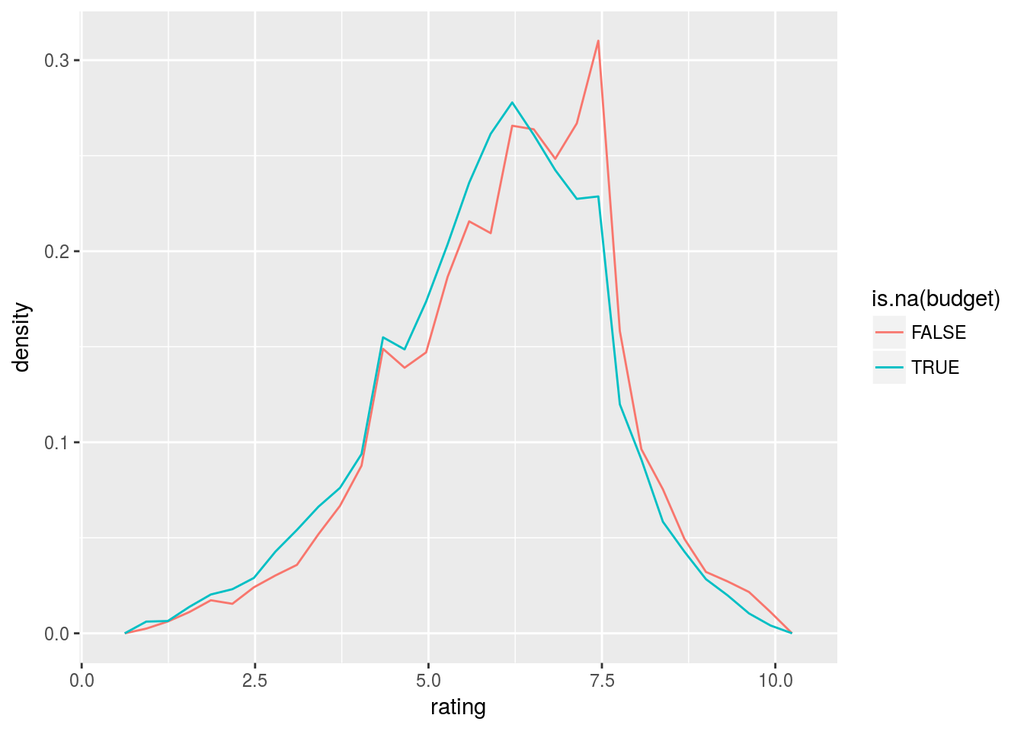

```r
ggplot(movies, aes(rating, ..density.., color=is.na(budget))) + geom_freqpoly()
```

5. What is `NA & FALSE` and `NA | TRUE`? Why? Why doesn’t `NA * 0` equal zero? What number time zero does not equal 0? What do you expect NA ^ 0 to equal? Why?

```r
NA & FALSE
```

```
## [1] FALSE
```

```r
NA | TRUE
```

```
## [1] TRUE
```

FALSE “and-ed” with anything is always FALSE. So, `NA & FALSE` is FALSE. TRUE “or-ed” with anything is always TRUE. So, `NA | TRUE` is TRUE.

`NA * 0` does not equal zero, because `Inf * 0` does not equal 0. Since we don’t know what the missing value (NA) is, we can’t say that its product with 0 is 0.

`NA ^ 0` is 1.

# 10.3.2 Exercises

1. Practice your variable creation skills by creating the following new variables:
- The approximate volume of the diamond (using x, y, and z).

```r
diamonds2 <- mutate(diamonds, volume = x*y*z)
select(diamonds2,x,y,z,volume) %>% head()
```

```
## # A tibble: 6 x 4
##       x     y     z   volume
##   <dbl> <dbl> <dbl>    <dbl>
## 1  3.95  3.98  2.43 38.20203
## 2  3.89  3.84  2.31 34.50586
## 3  4.05  4.07  2.31 38.07688
## 4  4.20  4.23  2.63 46.72458
## 5  4.34  4.35  2.75 51.91725
## 6  3.94  3.96  2.48 38.69395
```

- The approximate density of the diamond.

```r
#Density is mass/volume.
diamonds2 <- mutate(diamonds2, density=carat/volume)
select(diamonds2,carat,volume,density) %>% head()
```

```
## # A tibble: 6 x 3
##   carat   volume     density
##   <dbl>    <dbl>       <dbl>
## 1  0.23 38.20203 0.006020622
## 2  0.21 34.50586 0.006085924
## 3  0.23 38.07688 0.006040410
## 4  0.29 46.72458 0.006206583
## 5  0.31 51.91725 0.005971040
## 6  0.24 38.69395 0.006202520
```

- The price per carat.

```r
diamonds2 <- mutate(diamonds2,ppc=round(price/carat, digits=2))
select(diamonds2,price,carat,ppc) %>% head()
```

```
## # A tibble: 6 x 3
##   price carat     ppc
##   <int> <dbl>   <dbl>
## 1   326  0.23 1417.39
## 2   326  0.21 1552.38
## 3   327  0.23 1421.74
## 4   334  0.29 1151.72
## 5   335  0.31 1080.65
## 6   336  0.24 1400.00
```

- Log transformation of carat and price.

```r
diamonds2 <- mutate(diamonds2,caratL=log(carat),priceL=log(price))
select(diamonds2,carat,caratL,price,priceL) %>% head()
```

```
## # A tibble: 6 x 4
##   carat    caratL price   priceL
##   <dbl>     <dbl> <int>    <dbl>
## 1  0.23 -1.469676   326 5.786897
## 2  0.21 -1.560648   326 5.786897
## 3  0.23 -1.469676   327 5.789960
## 4  0.29 -1.237874   334 5.811141
## 5  0.31 -1.171183   335 5.814131
## 6  0.24 -1.427116   336 5.817111
```

2. How can you improve the data density of `ggplot(diamonds, aes(x,z)) + stat_bin2d()`? What transformation makes it easier to extract outliers?

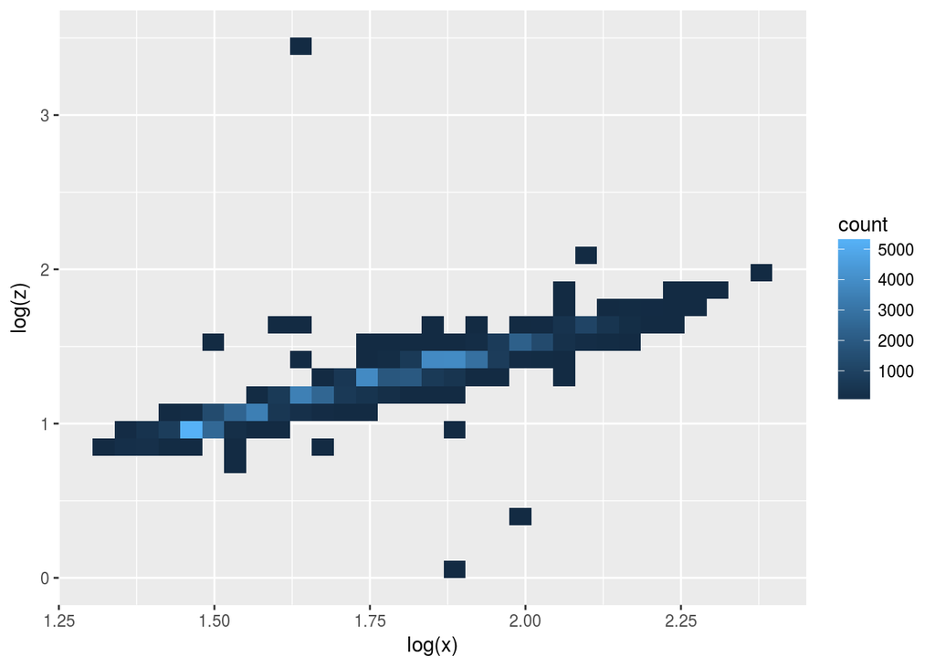

```r
ggplot(diamonds, aes(log(x),log(z))) + stat_bin2d()
```

3. The depth variable is just the width of the diamond (average of x and y) divided by its height (z) multiplied by 100 and rounded to the nearest integer. Compute the depth yourself and compare it to the existing depth variable. Summarize your findings with a plot.

NOTE: Diamonds documention says that “depth percentage = z / mean(x, y)”, which is the reciprocal of the description in this problem.

```r
diamondsNew <- mutate(diamonds2,depth2=round(100*z*2/(x+y),1))
select(diamondsNew,x,y,z,depth2,depth) %>% head()
```

```
## # A tibble: 6 x 5
##       x     y     z depth2 depth
##   <dbl> <dbl> <dbl>  <dbl> <dbl>
## 1  3.95  3.98  2.43   61.3  61.5
## 2  3.89  3.84  2.31   59.8  59.8
## 3  4.05  4.07  2.31   56.9  56.9
## 4  4.20  4.23  2.63   62.4  62.4
## 5  4.34  4.35  2.75   63.3  63.3
## 6  3.94  3.96  2.48   62.8  62.8
```

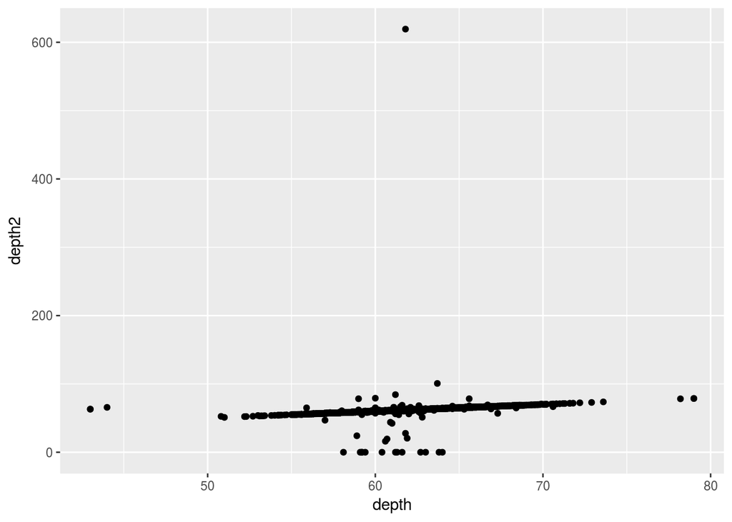

```r
ggplot(diamondsNew, aes(depth,depth2)) + geom_point()
```

4. Compare the distribution of symmetry for diamonds with $x > y$ vs. $x < y$.

```r
diamonds2 <- mutate(diamonds2,sym=x-y)
select(diamonds2,x,y,sym) %>% head()
```

```
## # A tibble: 6 x 3
##       x     y   sym
##   <dbl> <dbl> <dbl>
## 1  3.95  3.98 -0.03
## 2  3.89  3.84  0.05
## 3  4.05  4.07 -0.02
## 4  4.20  4.23 -0.03
## 5  4.34  4.35 -0.01
## 6  3.94  3.96 -0.02
```

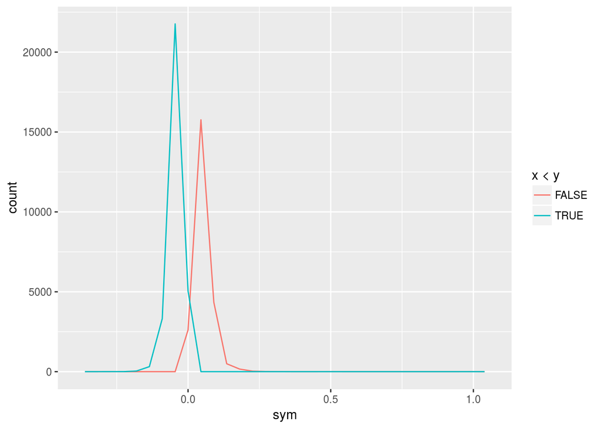

```r
#Filter outliers using filter, then plot:
ggplot(filter(diamonds2,sym>-1,sym<1), aes(sym,color=x<y)) + geom_freqpoly()
```

# 10.4.3 Exercises

1. For each year in the `ggplot2movies::movies` data determine the percent of movies with missing budgets. Visualize the result.

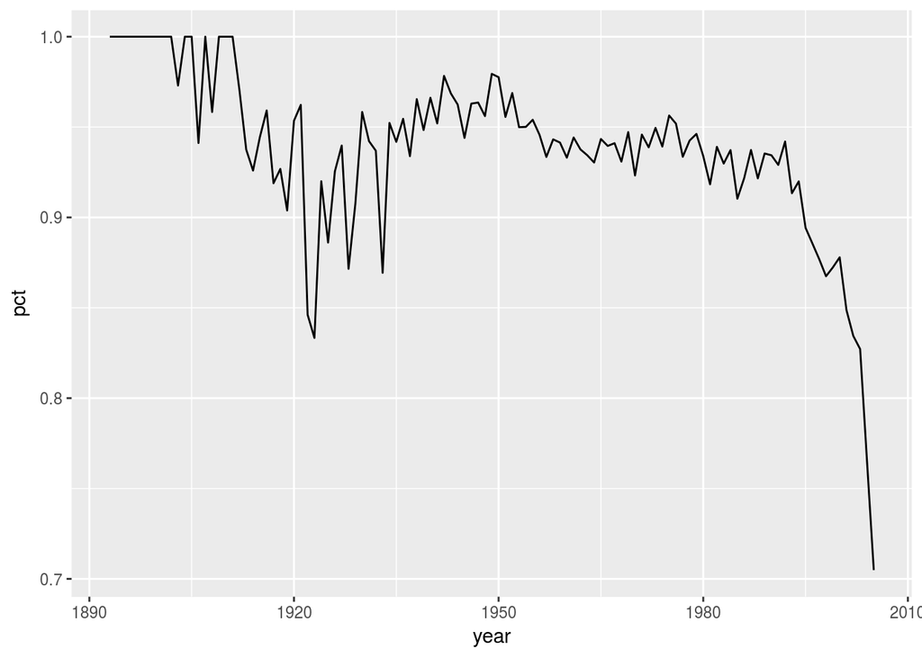

```r
missingBudget <- movies %>% group_by(year) %>% summarize(pct=mean(is.na(budget)))
ggplot(missingBudget, aes(year,pct)) + geom_line()
```

2. How does the average length of a movie change over time? Display your answer with a plot, including some display of uncertainty.

```r
lenByDecade <- movies %>% mutate(decade=floor(movies$year/10)*10) %>% group_by(decade) %>% summarize(avgLen=mean(length),se=sd(length))
head(lenByDecade)
```

```
## # A tibble: 6 x 3
##   decade    avgLen        se
##    <dbl>     <dbl>     <dbl>
## 1   1890  1.346939  1.377664
## 2   1900  5.448276  6.120500
## 3   1910 40.665835 47.695577
## 4   1920 66.913208 40.471917
## 5   1930 62.466497 37.662794
## 6   1940 68.936484 41.235390
```

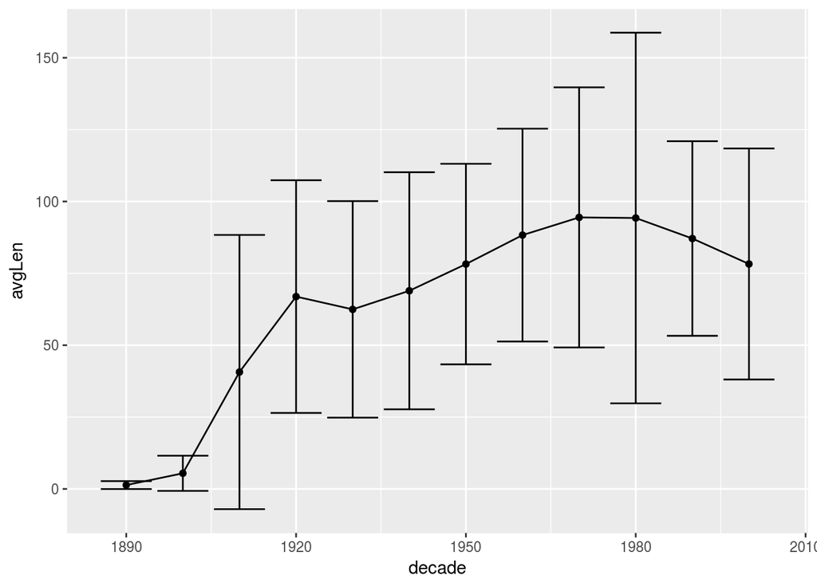

```r
ggplot(lenByDecade,aes(decade,avgLen,ymin=avgLen-se,ymax=avgLen+se)) + geom_point() + geom_line() + geom_errorbar()
```

3. For each combination of diamond quality (e.g. cut, color, and clarity), count the number of diamonds, the average price and the average size. Visualize the results.

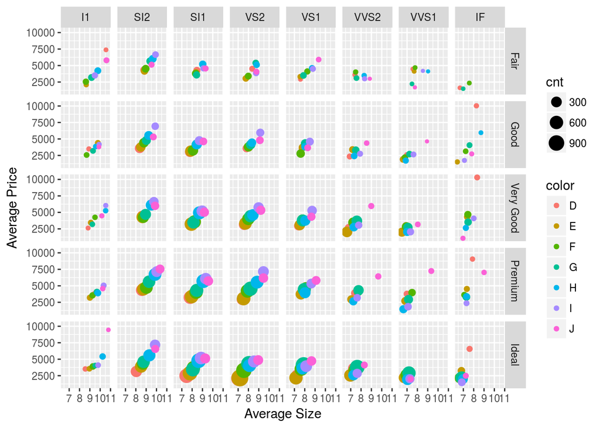

```r
diamonds2 <- diamonds %>% mutate(size=sqrt(x^2 + y^2)) %>% group_by(cut,color,clarity) %>% summarize(cnt=n(),avgPrice=mean(price),avgSize=mean(size))

ggplot(diamonds2, aes(avgSize,avgPrice, color=color)) + geom_point(aes(size=cnt)) + facet_grid(cut ~ clarity) + xlab("Average Size") + ylab("Average Price")
```

4. Compute a histogram of carat by “hand” using a binwidth of 0.1. Display the results with `geom_bar(stat = "identity")`. (Hint: you might need to create a new variable first.)

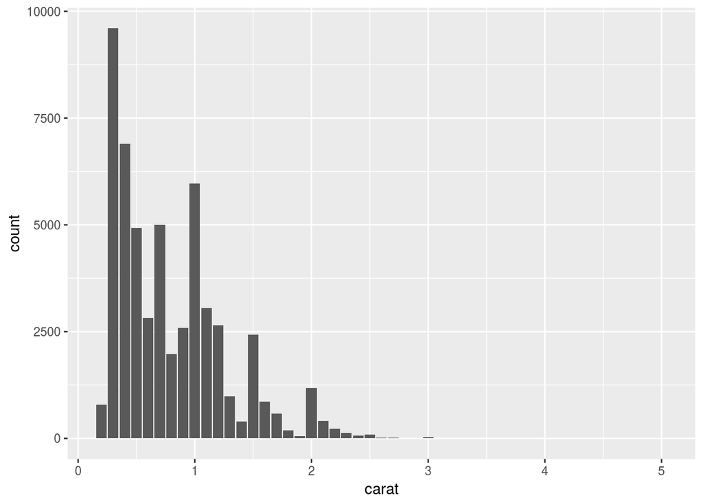

```r
diamonds2 <- diamonds %>% mutate(bin=round(carat,digits=1))
histData <- diamonds2 %>% group_by(bin) %>% summarize(n=n())

ggplot(histData, aes(bin,n)) + geom_bar(stat="identity") + xlab("carat") + ylab("count")
```

5. In the baseball example, the batting average seems to increase as the number of at bats increases. Why?

Recall ba = H/AB.

It’s likely that as batters are at bat more (and bat against more pitchers) their performance improves.

# 10.5.1 Exercises

1. Translate each of the examples in this chapter to use the pipe.

Page 212:

```r
diamonds %>% group_by(clarity) %>% summarize(price=mean(price))
```

```
## # A tibble: 8 x 2
##   clarity    price
##     <ord>    <dbl>
## 1      I1 3924.169
## 2     SI2 5063.029
## 3     SI1 3996.001
## 4     VS2 3924.989
## 5     VS1 3839.455
## 6    VVS2 3283.737
## 7    VVS1 2523.115
## 8      IF 2864.839
```

```r
diamonds %>% group_by(cut,depth) %>% summarize(n=n()) %>% filter(depth>55,depth<70)
```

```
## # A tibble: 455 x 3
## # Groups:   cut [5]
##      cut depth     n
##    <ord> <dbl> <int>
##  1  Fair  55.1     3
##  2  Fair  55.2     6
##  3  Fair  55.3     5
##  4  Fair  55.4     2
##  5  Fair  55.5     3
##  6  Fair  55.6     4
##  7  Fair  55.8     7
##  8  Fair  55.9     9
##  9  Fair  56.0     5
## 10  Fair  56.1     5
## # ... with 445 more rows
```

Page 216:

```r
#install.packages("Lahman")
library("Lahman")
Batting %>% filter(AB>0) %>% group_by(playerID) %>% summarize(ba=sum(H, na.rm=TRUE) / sum(AB, ra.rm=TRUE))
```

```
## # A tibble: 16,902 x 2
##     playerID         ba
##        <chr>      <dbl>
##  1 aardsda01 0.00000000
##  2 aaronha01 0.30497372
##  3 aaronto01 0.22857143
##  4  aasedo01 0.00000000
##  5  abadan01 0.09090909
##  6  abadfe01 0.10000000
##  7 abadijo01 0.22000000
##  8 abbated01 0.25353038
##  9 abbeybe01 0.16814159
## 10 abbeych01 0.28082192
## # ... with 16,892 more rows
```

2. What does the following pipe do?

```r
library(magrittr)
x <- runif(10)
x %>%
  subtract(mean(.)) %>%
  raise_to_power(2) %>%
  mean() %>%
  sqrt()
```

```
## [1] 0.2830116
```

Subtract the mean(x) from each x value, then square each value, then find the mean of all values, then take the square root.

3. Which player in the `Batting` dataset has had the most consistently good performance over the course of their career?

Of all batters who have atleast 80 at bats, cobbty01 has the highest batting average (0.36636) with 4189 hits out of 11,434 total at bats (over the course of 24 years).

```r
baPerBatter <- Batting %>%
    group_by(playerID) %>% summarize(totalHits=sum(H, na.rm=TRUE),totalAB=sum(AB, na.rm=TRUE),ba=sum(H, na.rm=TRUE)/sum(AB, na.rm=TRUE),n=n()) %>%
  filter(totalHits>0,totalAB>50) %>%
  arrange(desc(ba))

head(baPerBatter)
```

```
## # A tibble: 6 x 5
##    playerID totalHits totalAB        ba     n
##       <chr>     <int>   <int>     <dbl> <int>
## 1 forstte01        31      78 0.3974359    16
## 2 rowanda01        25      65 0.3846154     1
## 3 hugheto03        22      59 0.3728814     1
## 4  cobbty01      4189   11434 0.3663635    24
## 5 asadora01        20      55 0.3636364     1
## 6 dormare01        28      77 0.3636364     1
```

Additionally, we can see that his batting average did not vary too greatly over the years (especially after the improvement during the first 5 years).

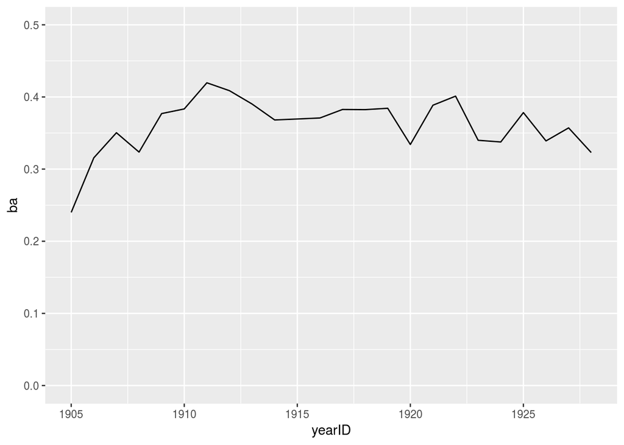

```r
cobbty01 <- Batting %>% filter(playerID=="cobbty01") %>%
  mutate(ba=H/AB)

ggplot(cobbty01, aes(yearID,ba,ymin=0,ymax=0.5)) + geom_line()
```